# Cancer Evolution analysis of a glioblastoma

Giulio Caravagna (gcaravagna@units.it)  
Cancer Data Science Laboratory, University of Trieste.

2022

# Table of Contents

1. Requirements
2. Input data
3. Assessing the quality of these calls
4. Subclonal deconvolution of diploid SNVs
5. Subclonal deconvolution with CCF

Our analyses mainly leverage on a set packages that are currently maintained at the Cancer Data Science Laboratory, University of Trieste. Packages websites provide detailed function manuals and reference vignettes, upon which these analyses are largely based on.

[figure not shown]

[figure not shown]

[figure not shown]

## Requirements

We assume that you have installed the following packages and their dependencies

```r
# Our packages
library(mobster)
library(CNAqc)
library(ctree)

# Other packages
library(dplyr)
library(readr)
library(ggplot2)
```

## Input data

We use some data that [we have recently analysed](https://www.nature.com/articles/s41588-020-0675-5); there are more data release with our paper, you could play around with those once you have understood this analysis.

> Subclonal reconstruction of tumors by using machine learning and population genetics Caravagna et al. Nature Genetics volume 52, pages 898–907 (2020).

For these data we have selected the following:

- single-nucleotide somatic mutations;
- absolute clonal CNA segments;
- tumour purity.

The data have been cleaned by me for this presentation (similarly to how I did that for the actual paper). Originally, this sample and its associated relapse have been released with a [Cancer Cell paper](https://pubmed.ncbi.nlm.nih.gov/30905762/)

> Evolutionary Trajectories of IDH WT Glioblastomas Reveal a Common Path of Early Tumorigenesis Instigated Years ahead of Initial Diagnosis. Koerber et al. Cancer Cell. 2019 Apr 15;35(4):692-704.e12.

Inputs are provided in CSV format, we load them using the `readr` package.

```r
# -> somatic mutations
snvs = readr::read_csv('data/mutations.csv', col_types = readr::cols())

# -> copy number segment (CNA), precisely absolute calls for clonal segments
cna = readr::read_csv('data/cna.csv', col_types = readr::cols())

# Sample information
sample_info = readr::read_csv('data/sample.csv', col_types = readr::cols())

# -> sample id
sample_id = sample_info$sample

# -> a scalar reporting sample purity (0 <= x <= 1)
sample_purity = sample_info$purity

# -> reference genome used
reference = "hg19"
```

`readr` returns all tibble-compliant data, using the `tidyverse` approach. Let’s have a look at what we have in the data. To map mutations on top of CNA we need to have genome locations, and to run a deconvolution with MOBSTER we need the VAF of the somatic mutation. Note that these calls are obtained by subtracting the somatic mutations detected in the tumour sample from a putative normal sample, as discussed in the theoretical lecture.

```r
print(snvs)
```

```
#> # A tibble: 9,314 × 11
#>    chr      from      to ref   alt      DP    NV    VAF GENE           is_driver
#>    <chr>   <dbl>   <dbl> <chr> <chr> <dbl> <dbl>  <dbl> <chr>          <lgl>
#>  1 chr1  1124790 1124791 G     A       192    93 0.484  TTLL10         FALSE
#>  2 chr1  2064943 2064944 A     C        63     6 0.0952 PRKCZ          FALSE
#>  3 chr1  2164640 2164641 A     G       133     7 0.0526 SKI            FALSE
#>  4 chr1  2219484 2219485 A     G       190    90 0.474  SKI            FALSE
#>  5 chr1  2448305 2448306 G     C       223   115 0.516  PANK4          FALSE
#>  6 chr1  2453474 2453475 G     C       194    81 0.418  PANK4          FALSE
#>  7 chr1  2453527 2453528 G     C       194    78 0.402  PANK4          FALSE
#>  8 chr1  2491708 2491709 C     G       223   110 0.493  TNFRSF14       FALSE
#>  9 chr1  2808062 2808063 C     G       190    97 0.511  RP11-740P5.3(… FALSE
#> 10 chr1  2808759 2808760 C     T       207   106 0.512  RP11-740P5.3(… FALSE
#> # … with 9,304 more rows, and 1 more variable: driver_label <chr>
```

For instance we see:

- `chr` - chromosome name (format `chrXX`)
- `from`/ `to` - nucleotide position (relative to the chromosome beginning)
- `ref`/ `alt` - reference and alternative allele

These mutations span all the genome and are just SNVs (it is good to use these instead of indels).

```r
 # Mapping of the mutations per chromosome
snvs %>%
  dplyr::group_by(chr) %>%
  dplyr::summarise(n = dplyr::n()) %>%
  dplyr::ungroup() %>%
  dplyr::arrange(dplyr::desc(n))
```

```
#> # A tibble: 23 × 2
#>    chr       n
#>    <chr> <int>
#>  1 chrX    863
#>  2 chr4    782
#>  3 chr7    759
#>  4 chr2    738
#>  5 chr5    675
#>  6 chr1    651
#>  7 chr3    626
#>  8 chr6    545
#>  9 chr12   437
#> 10 chr8    406
#> # … with 13 more rows
```

```r
# Type of mutations
snvs %>%
  dplyr::group_by(ref, alt) %>%
  dplyr::summarise(n = dplyr::n()) %>%
  dplyr::ungroup() %>%
  dplyr::arrange(dplyr::desc(n))
```

[output not shown]

We also have read counts data obtained from the caller that was used to generate. You can verify that `VAF` = `NV`/`DP`. Eg, 6/60 = 0.1

```r
snvs %>%
  dplyr::select(DP, NV, VAF) %>%
  print
```

```
#> # A tibble: 9,314 × 3
#>       DP    NV    VAF
#>    <dbl> <dbl>  <dbl>
#>  1   192    93 0.484
#>  2    63     6 0.0952
#>  3   133     7 0.0526
#>  4   190    90 0.474
#>  5   223   115 0.516
#>  6   194    81 0.418
#>  7   194    78 0.402
#>  8   223   110 0.493
#>  9   190    97 0.511
#> 10   207   106 0.512
#> # … with 9,304 more rows
```

Before moving on, notice that there are driver mutations annotated in these calls; one for instance is an exonic `TP53` mutation - identified after Annovar annotations by looking at [COSMIC](https://cancer.sanger.ac.uk/cosmic). This driver has been discovered by the authors in the original paper. Another driver event has been retrieved from the original paper, it is a `TERT` promoter mutation (other potential drivers are annotated in the original paper but the fall off CNA regions, and so are not discussed here).

The input format to include drivers is the one required by `CNAqc`.

```r
snvs %>%
  dplyr::filter(is_driver) %>%
  print
```

```
#> # A tibble: 2 × 11
#>   chr     from     to ref   alt      DP    NV   VAF GENE  is_driver driver_label
#>   <chr>  <dbl>  <dbl> <chr> <chr> <dbl> <dbl> <dbl> <chr> <lgl>     <chr>
#> 1 chr5  1.30e6 1.30e6 G     A       102    42 0.412 TERT  TRUE      TERT_prom.
#> 2 chr17 7.58e6 7.58e6 C     T        95    83 0.874 TP53  TRUE      TP53_nonsyn.
```

# Assessing the quality of these calls

We use the package [CNAqc](https://caravagn.github.io/CNAqc/).

The package takes as input all the data we have just loaded, and maps the mutations on top of the segments; it implements also a number of other analyses which we will see right now.

The idea of `CNAqc` is this. Mutations are somewhat easier to call compared to CNAs, because they are associated to read counts which come out rather directly of a BAM file, while CNAs require complex inference from BAF and log-ratio data. The same holds for sample purity estimate, which is usually obtained together with CNAs.

Thus, in general we can use mutation calls to quality control (QC) CNAs and tumour purity estimates. Basically the two types of data, mutations on one side, and CNAs/purity on the other side, must be consistent.

We begin by creating a `CNAqc` object; I invite you to read out the outputs of the tool to understand what is happening.

```r
# CNAqc data object
x = CNAqc::init(snvs = snvs,
                cna = cna,
                purity = sample_purity,
                ref = reference,
                sample = 'Example WGS GBM')
```

```
#>  [ CNAqc - CNA Quality Check ]
#> ℹ Using reference genome coordinates for: hg19.
#> ℹ Drivers are annotated, but 'gene' column is missing, using mutation location.
#> ✔ Fortified calls for 9314 somatic mutations: 9314 SNVs (100%) and 0 indels.
#> ! CNAs have no CCF, assuming clonal CNAs (CCF = 1).
#> ✔ Fortified CNAs for 272 segments: 272 clonal and 0 subclonal.
#> ✔ 6728 mutations mapped to clonal CNAs.
```

```r
# S3 print
print(x)
```

```
#> ── [ CNAqc ]  Example WGS GBM (reference: hg19) ────────────────────────────────
#>
#> ── Mutations (tot. 6728; 6728 in clonal CNAs)
#> ℹ   SNVs : 6728 (clonal CNAs), 0 (subclonal CNAs).
#> ℹ indels : 0 (clonal CNAs), 0 (subclonal CNAs).
#>
#> ── Clonal CNAs
#>
#>   1:1  [n = 5984, L = 1964 Mb] ■■■■■■■■■■■■■■■■■■■■■■■■■■■  { TERT_prom. }
#>   1:0  [n =  494, L =  289 Mb] ■■  { TP53_nonsyn. }
#>   2:1  [n =  155, L =   35 Mb] ■
#>   2:2  [n =   92, L =   14 Mb]
#>  14:2  [n =    2, L =    0 Mb]
#>  17:2  [n =    1, L =    0 Mb]
#> ℹ Sample Purity: 95% ~ Ploidy: 2.
#> ℹ There are 2 annotated driver(s) mapped to clonal CNAs.
#>          chr    from      to ref alt  DP NV       VAF driver_label is_driver
#>         chr5 1295228 1295229   G   A 102 42 0.4117647   TERT_prom.      TRUE
#>        chr17 7577538 7577539   C   T  95 83 0.8736842 TP53_nonsyn.      TRUE
```

There are some basic plotting functions in the package, you shoud use those to inspect the data.

In general we are interested in the `VAF` and `DP` profiles - recall that `DP` is the coverage per locus. We assemble a nice 2-panels figure by using `ggpubr`; note that the package also annotates the driver data in the plot, so you can immediately see that this `TP53` driver SNVs maps to an LOH region (kind of expected for a suppressor gene).

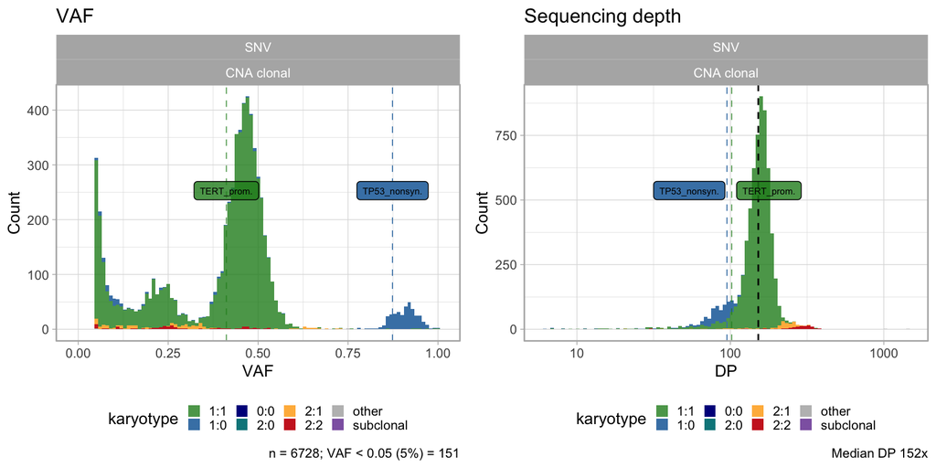

```r
ggpubr::ggarrange(
  CNAqc::plot_data_histogram(x),
  CNAqc::plot_data_histogram(x, which = 'DP'),
  ncol = 2
  ) %>%
  print()
```

We can do more complex plots. For instance we can layout a panel with segments in bottom, and all other genome-wide plots on top. Via `cowplot` we can align plots on the vertical axis, and stretch their relative height to obtain a nice layout.

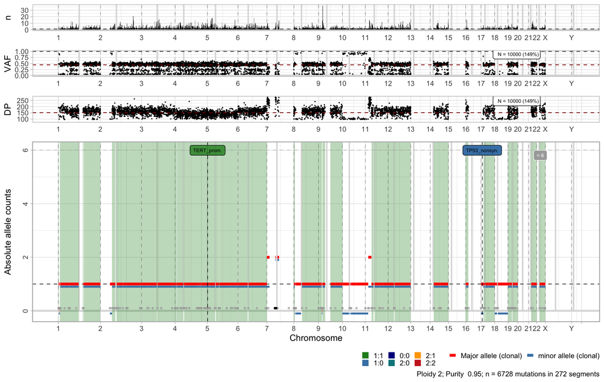

```r
cowplot::plot_grid(
  CNAqc::plot_gw_counts(x),
  CNAqc::plot_gw_vaf(x, N = 10000),
  CNAqc::plot_gw_depth(x, N = 10000),
  CNAqc::plot_segments(x),
  align = 'v',
  nrow = 4,
  rel_heights = c(.15, .15, .15, .8)
  )
```

So it is easy to see that this tumour is largely diploid

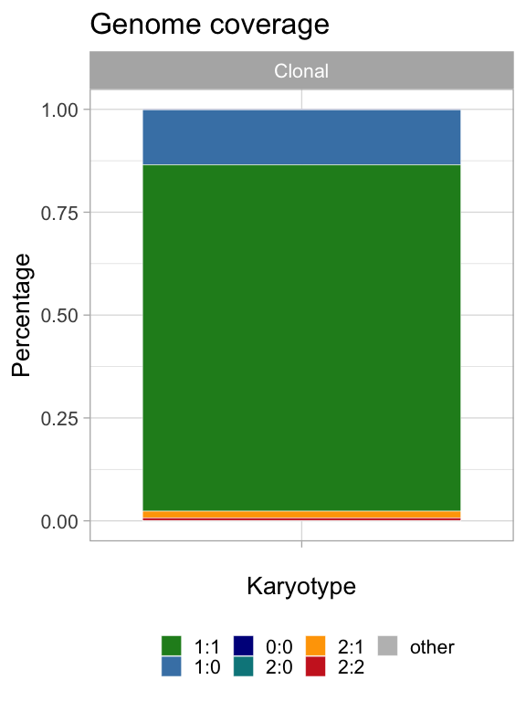

```r
CNAqc::plot_karyotypes(x)
```

You can play around with the `CNAqc` functions following examples available at the tool website.

Here we just check that the quality of the calls is good to study this tumour. We use a method based on a peak detection algorithm that is derived from a combinatorial arguments that links tumour ploidy, mutation multiplicity, sample purity, and VAF.

We do not dig into the details of this, you can fin a lot of explanations on the manual and tool website.

```r
x = CNAqc::analyze_peaks(x, matching_strategy = 'closest')
```

```
#>
#> ── Peak analysis: simple CNAs ──────────────────────────────────────────────────
#> ℹ Analysing 6633 mutations mapping to karyotype(s) 1:1, 1:0, and 2:1.
#> ℹ Mixed type peak detection for karyotype 1:0 (494 mutations)
#> ℹ Mixed type peak detection for karyotype 1:1 (5984 mutations)
#> ℹ Mixed type peak detection for karyotype 2:1 (155 mutations)
#> # A tibble: 4 × 16
#> # Rowwise:
#>   mutation_multiplicity karyotype  peak delta_vaf     x     y counts_per_bin
#>                   <dbl> <chr>     <dbl>     <dbl> <dbl> <dbl>          <int>
#> 1                     1 1:1       0.475    0.025  0.47   5.81            413
#> 2                     1 1:0       0.905    0.0907 0.907  3.14             24
#> 3                     1 2:1       0.322    0.0115 0.312  2.80              6
#> 4                     2 2:1       0.644    0.0230 0.64   1.02              4
#> # … with 9 more variables: discarded <lgl>, from <chr>, offset_VAF <dbl>,
#> #   offset <dbl>, weight <dbl>, epsilon <dbl>, VAF_tolerance <dbl>,
#> #   matched <lgl>, QC <chr>
#> ✔ Peak detection PASS with r = 0.0101289392240201 - maximum purity error ε = 0.05.
#>
#> ── Peak analysis: complex CNAs ─────────────────────────────────────────────────
#> ℹ No karyotypes with >100 mutation(s).
#>
#> ── Peak analysis: subclonal CNAs ───────────────────────────────────────────────
#> ℹ No subclonal CNAs in this sample.
```

```r
print(x)
```

```
#> ── [ CNAqc ]  Example WGS GBM (reference: hg19) ────────────────────────────────
#>
#> ── Mutations (tot. 6728; 6728 in clonal CNAs)
#> ℹ   SNVs : 6728 (clonal CNAs), 0 (subclonal CNAs).
#> ℹ indels : 0 (clonal CNAs), 0 (subclonal CNAs).
#>
#> ── Clonal CNAs
#>
#>   1:1  [n = 5984, L = 1964 Mb] ■■■■■■■■■■■■■■■■■■■■■■■■■■■  { TERT_prom. }
#>   1:0  [n =  494, L =  289 Mb] ■■  { TP53_nonsyn. }
#>   2:1  [n =  155, L =   35 Mb] ■
#>   2:2  [n =   92, L =   14 Mb]
#>  14:2  [n =    2, L =    0 Mb]
#>  17:2  [n =    1, L =    0 Mb]
#> ℹ Sample Purity: 95% ~ Ploidy: 2.
#> ℹ There are 2 annotated driver(s) mapped to clonal CNAs.
#>          chr    from      to ref alt  DP NV       VAF driver_label is_driver
#>         chr5 1295228 1295229   G   A 102 42 0.4117647   TERT_prom.      TRUE
#>        chr17 7577538 7577539   C   T  95 83 0.8736842 TP53_nonsyn.      TRUE
#>
#> ──  PASS  Peaks QC closest: 102%, λ = 0.0101. Purity correction: 1%. ───────────
#> ℹ 1:1 ~ n = 5984  ( 90%) →  PASS  0.01
#> ℹ 1:0 ~ n = 494   (  7%) →  PASS  -0.001
#> ℹ 2:1 ~ n = 155   (  2%) →  PASS  0.042    PASS  0.009
```

We can visualise the result of this analysis.

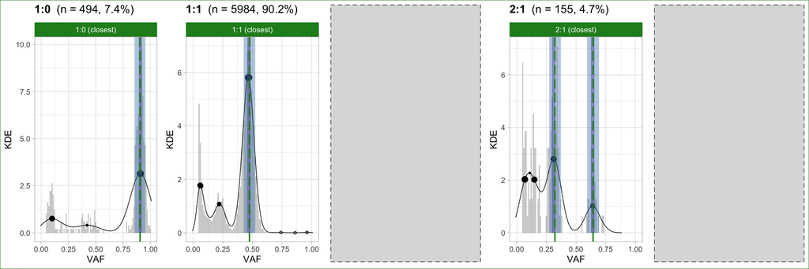

```r
CNAqc::plot_peaks_analysis(x)
```

## Cancer Cell Fractions computation

We can also compute CCFs from these calls, because they are good quality. If everything makes sense, we should obtain the same result we have with diploid mutations.

We compute CCFs values with CNAqc, and plot their analysis. Details on how the computation is carried out are available at the package website. Shortly, it uses an entropy measure based on a mixture model for the expected peaks of mutations multiplicities.

```r
x = CNAqc::compute_CCF(x, method = "ENTROPY")
# Now accessible
print(x)
```

```
#> ── [ CNAqc ]  Example WGS GBM (reference: hg19) ────────────────────────────────
#>
#> ── Mutations (tot. 6728; 6728 in clonal CNAs)
#> ℹ   SNVs : 6728 (clonal CNAs), 0 (subclonal CNAs).
#> ℹ indels : 0 (clonal CNAs), 0 (subclonal CNAs).
#>
#> ── Clonal CNAs
#>
#>   1:1  [n = 5984, L = 1964 Mb] ■■■■■■■■■■■■■■■■■■■■■■■■■■■  { TERT_prom. }
#>   1:0  [n =  494, L =  289 Mb] ■■  { TP53_nonsyn. }
#>   2:1  [n =  155, L =   35 Mb] ■
#>   2:2  [n =   92, L =   14 Mb]
#>  14:2  [n =    2, L =    0 Mb]
#>  17:2  [n =    1, L =    0 Mb]
#> ℹ Sample Purity: 95% ~ Ploidy: 2.
#> ℹ There are 2 annotated driver(s) mapped to clonal CNAs.
#>          chr    from      to ref alt  DP NV       VAF driver_label is_driver
#>         chr5 1295228 1295229   G   A 102 42 0.4117647   TERT_prom.      TRUE
#>        chr17 7577538 7577539   C   T  95 83 0.8736842 TP53_nonsyn.      TRUE
#>
#> ──  PASS  Peaks QC closest: 102%, λ = 0.0101. Purity correction: 1%. ───────────
#> ℹ 1:1 ~ n = 5984  ( 90%) →  PASS  0.01
#> ℹ 1:0 ~ n = 494   (  7%) →  PASS  -0.001
#> ℹ 2:1 ~ n = 155   (  2%) →  PASS  0.042    PASS  0.009
#> ✔ Cancer Cell Fraction (CCF) data available for karyotypes:1:0, 1:1, 2:1, and 2:2.
#> ✔  PASS  CCF via ENTROPY.
#> ✔  PASS  CCF via ENTROPY.
#> ✔  PASS  CCF via ENTROPY.
#> ✔  PASS  CCF via ENTROPY.
```

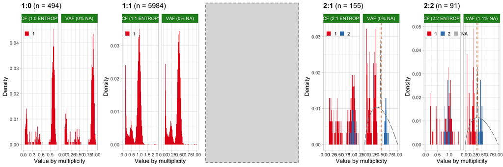

```r
# We can visualise the CCF computation report
plot_CCF(x)
```

So we have the overall CCF distribution now.

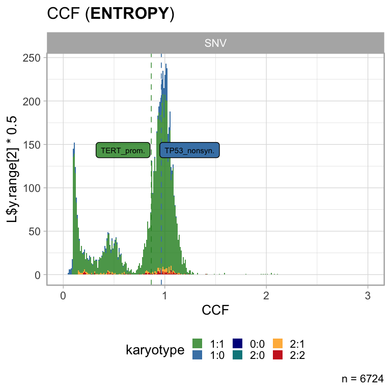

```r
# CCF across all karyotypes
plot_data_histogram(x, which = 'CCF')
```

# Subclonal deconvolution of diploid SNVs

We use the package [mobster](https://caravagn.github.io/mobster/).

Now we know we can trust those diploid SNVs, let’s use them.

```r
# Subset the data
diploid_mutations = x %>%
  CNAqc::subset_by_segment_karyotype(karyotypes = '1:1')
```

```
#>  [ CNAqc - CNA Quality Check ]
#> ℹ Using reference genome coordinates for: hg19.
#> ✔ Fortified calls for 6728 somatic mutations: 6728 SNVs (100%) and 0 indels.
#> ! CNAs have no CCF, assuming clonal CNAs (CCF = 1).
#> ✔ Fortified CNAs for 198 segments: 198 clonal and 0 subclonal.
#> Warning in map_mutations_to_clonal_segments(snvs, cna_clonal): [CNAqc] a
#> karyotype column is present in CNA calls, and will be overwritten
#> ✔ 5984 mutations mapped to clonal CNAs.
```

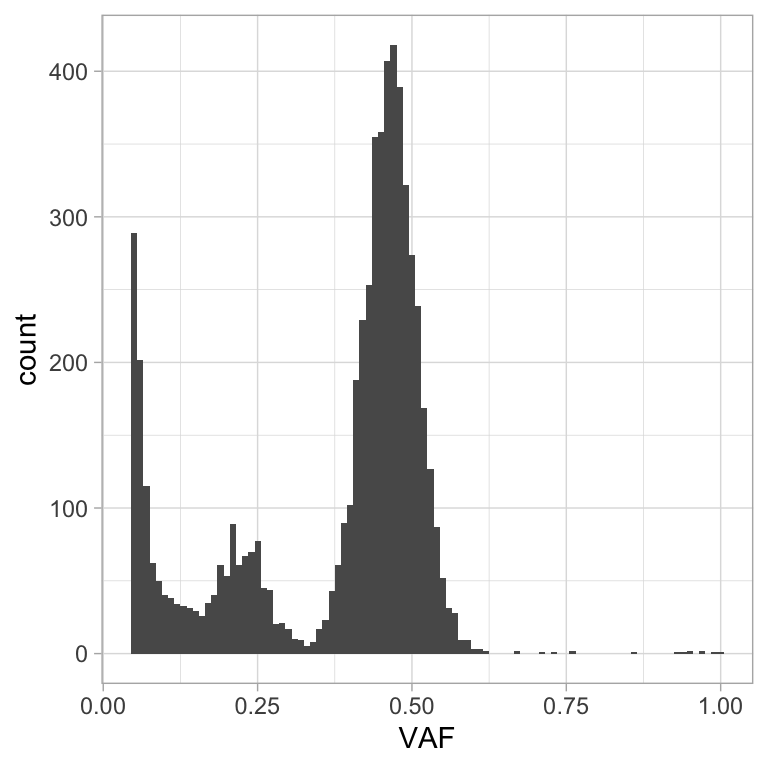

```r
# We can visualise the data using ggplot
diploid_mutations$snvs %>%
  ggplot(aes(VAF)) +
  geom_histogram(binwidth = 0.01) +
  theme_light()
```

We use SNVs with `VAF` above $5\%$, and below $65\%$; SNVs above that cut are clearly given by miscalled CNA segments.

We use one possible parametrisation of `mobster`, which is identified by a `"FAST"`. This tests a few model parameters, and is usually fast to run; It is not necessarily the best analysis but in general is good enough to get a quick grasp of what is in the data.

In this case it works well.

```r
mobster_analysis = mobster_fit(
  diploid_mutations$snvs %>%
    dplyr::filter(VAF > 0.05, VAF < 0.65),  # Remove minimum VAF and obviously wrong mappings
  seed = 1234,
  auto_setup = "FAST",
  description = sample_id
  )
```

```
#>  [ MOBSTER fit ]
#> ✔ Loaded input data, n = 5809.
#> ❯ n = 5809. Mixture with k = 1,2 Beta(s). Pareto tail: TRUE and FALSE. Output
#> clusters with π > 0.02 and n > 10.
#> ! mobster automatic setup FAST for the analysis.
#> ❯ Scoring (without parallel) 2 x 2 x 2 = 8 models by reICL.
#> ℹ MOBSTER fits completed in 17.9s.
#> ── [ MOBSTER ] H043-28GK n = 5809 with k = 2 Beta(s) and a tail ────────────────
#> ● Clusters: π = 74% [C1], 14% [Tail], and 12% [C2], with π > 0.
#> ● Tail [n = 746, 14%] with alpha = 2.
#> ● Beta C1 [n = 4296, 74%] with mean = 0.47.
#> ● Beta C2 [n = 767, 12%] with mean = 0.23.
#> ℹ Score(s): NLL = -6405.2; ICL = -12369.78 (-12703.07), H = 362.62 (29.32). Fit
#> converged by MM in 74 steps.
#> ℹ The fit object model contains also drivers annotated.
#> # A tibble: 1 × 16
#>   chr     from     to ref   alt      DP    NV   VAF GENE  is_driver driver_label
#>   <chr>  <dbl>  <dbl> <chr> <chr> <dbl> <dbl> <dbl> <chr> <lgl>     <chr>
#> 1 chr5  1.30e6 1.30e6 G     A       102    42 0.412 TERT  TRUE      TERT_prom.
#> # … with 5 more variables: gene <chr>, type <chr>, karyotype <chr>,
#> #   segment_id <chr>, cluster <chr>
```

Function `mobster_fit` returns a composite object (which we will soon wrap up in a new S3 object). So far you can see the fields returned by the tool in a named list.

The list contains:

- the best model fits;
- a set of alternative model fits;
- a table with all the scored models.

```r
# Named list
names(mobster_analysis)
```

```
#> [1] "fits.table"      "runs"            "best"            "model.selection"
```

```r
# A table reporting the score for each possible model returned by the tool
print(mobster_analysis$fits.table)
```

```
#>         NLL        BIC        AIC   entropy        ICL reduced.entropy
#> 5 -6405.201 -12732.397 -12792.401  362.6206 -12369.776        29.32377
#> 1 -5830.331 -11608.659 -11648.662  443.0220 -11165.637         0.00000
#> 4 -5877.420 -11702.838 -11742.841  387.5529 -11315.285       387.55290
#> 2 -5830.409 -11582.813 -11642.817 3318.9072  -8263.906      2931.88190
#> 3 -2269.313  -4512.624  -4532.626    0.0000  -4512.624         0.00000
#>        reICL size K  tail
#> 5 -12703.073    9 2  TRUE
#> 1 -11608.659    6 1  TRUE
#> 4 -11315.285    6 2 FALSE
#> 2  -8650.931    9 2  TRUE
#> 3  -4512.624    3 1 FALSE
```

```r
# The scoring used (defined in the paper): default reICL (~BIC + entropy of the latent variables)
print(mobster_analysis$model.selection)
```

```
#> [1] "reICL"
```

```r
# The best model fit -- what you will consider most of the times for downstream analysis
print(mobster_analysis$best)
```

```
#> ── [ MOBSTER ] H043-28GK n = 5809 with k = 2 Beta(s) and a tail ────────────────
#> ● Clusters: π = 74% [C1], 14% [Tail], and 12% [C2], with π > 0.
#> ● Tail [n = 746, 14%] with alpha = 2.
#> ● Beta C1 [n = 4296, 74%] with mean = 0.47.
#> ● Beta C2 [n = 767, 12%] with mean = 0.23.
#> ℹ Score(s): NLL = -6405.2; ICL = -12369.78 (-12703.07), H = 362.62 (29.32). Fit
#> converged by MM in 74 steps.
#> ℹ The fit object model contains also drivers annotated.
#> # A tibble: 1 × 16
#>   chr     from     to ref   alt      DP    NV   VAF GENE  is_driver driver_label
#>   <chr>  <dbl>  <dbl> <chr> <chr> <dbl> <dbl> <dbl> <chr> <lgl>     <chr>
#> 1 chr5  1.30e6 1.30e6 G     A       102    42 0.412 TERT  TRUE      TERT_prom.
#> # … with 5 more variables: gene <chr>, type <chr>, karyotype <chr>,
#> #   segment_id <chr>, cluster <chr>
```

The first thing to do now, is to plot the best model fit, and inspect it.

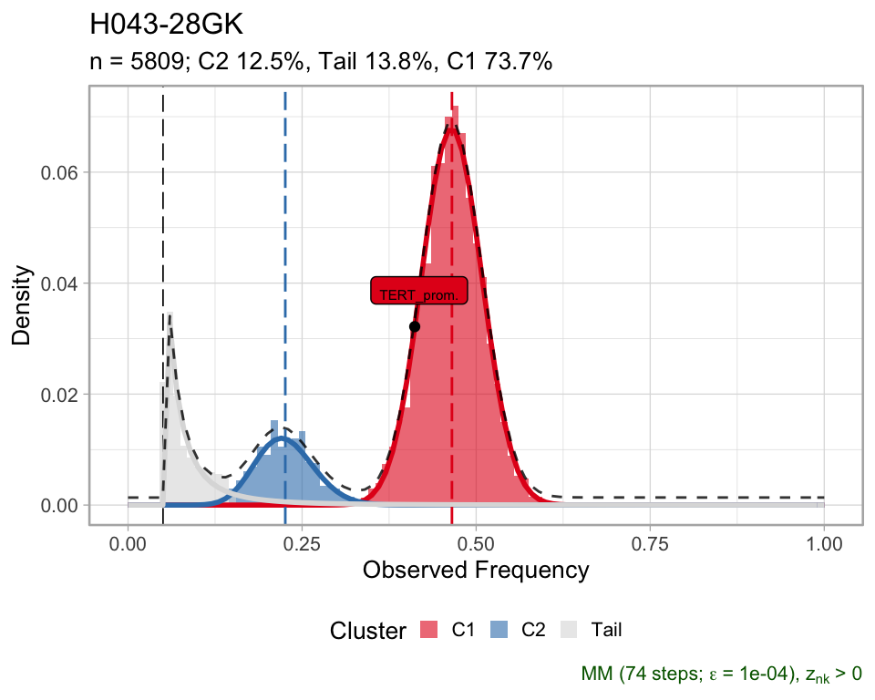

```r
plot(mobster_analysis$best)
```

Then, we can inspect a number of other features for the model, using other plotting functions of `mobster`. You should read the model definition to understand exactly what these plot means.

We can see the probability of assignment of a mutation to a cluster, and use it to check if some clusters are more difficult to define than others.

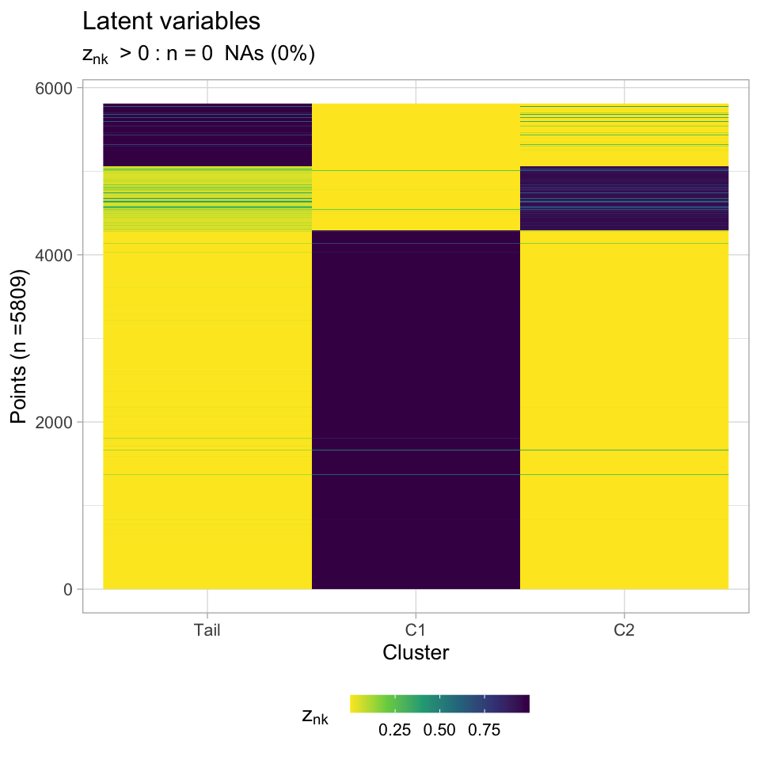

```r
plot_latent_variables(mobster_analysis$best)
```

Then we can see how big is each cluster (normalised for total mutational burden). In clustering these are called mixing proportions.

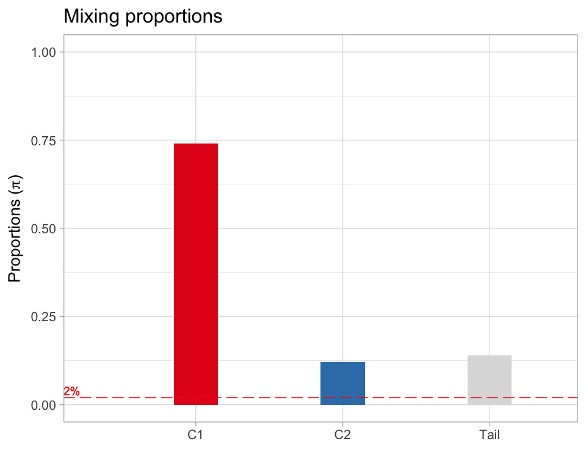

```r
plot_mixing_proportions(mobster_analysis$best)
```

The model minimises a negative log-likelihood function, which we can visualise (as a function of the optimisation step).

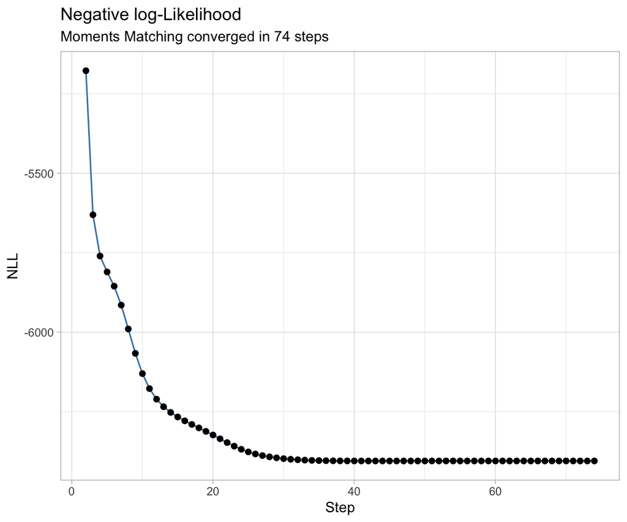

```r
plot_NLL(mobster_analysis$best)
```

In general it is also good to inspect the other models that we have selected as alternative to the best fit.

In this case we see that the only model that makes sense is the best one.

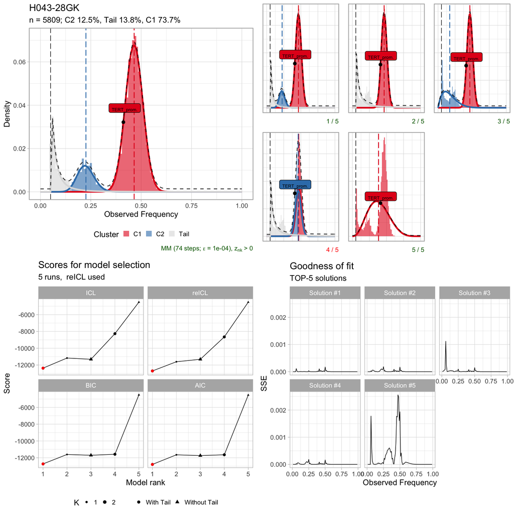

```r
plot_model_selection(mobster_analysis)
```

The theory underlying `mobster` allows to retrieve the evolutionary parameters of this tumour, such as:

- the tumour mutation rate $\mu$ (in units of cell doublings);
- the time the subclone originated (same unit as above);
- the subclone selection coefficient $s$.

```r
evolutionary_parameters(mobster_analysis)
```

```
#> # A tibble: 1 × 7
#>      mu exponent  time subclonefrequency subclonemutations cluster     s
#>   <dbl>    <dbl> <dbl>             <dbl>             <dbl> <chr>   <dbl>
#> 1  53.4     3.03  8.94             0.452              724. C2      0.370
```

# Subclonal deconvolution with CCF

The CCFs are used to create a valid input for `mobster`. We rescale the CCF value to match a VAF for a putative heterozygous clonal diploid mutation.

We go faster: we impose filters as above (adjusted for purity), fit the model and visualise it.

```r
# Getter and filter
ccf_input = CNAqc::CCF(x) %>%
  mutate(VAF = CCF/2) %>%
  filter(VAF > 0.05/0.95, VAF < 1)

# Actual run, as above
mobster_analysis_CCF = mobster_fit(
  ccf_input,
  auto_setup = 'FAST',
  description = sample_id
  )
```

```
#>  [ MOBSTER fit ]
#> ✔ Loaded input data, n = 6517.
#> ❯ n = 6517. Mixture with k = 1,2 Beta(s). Pareto tail: TRUE and FALSE. Output
#> clusters with π > 0.02 and n > 10.
#> ! mobster automatic setup FAST for the analysis.
#> ❯ Scoring (without parallel) 2 x 2 x 2 = 8 models by reICL.
#> ℹ MOBSTER fits completed in 16.9s.
#> ── [ MOBSTER ] H043-28GK n = 6517 with k = 2 Beta(s) and a tail ────────────────
#> ● Clusters: π = 73% [C1], 15% [Tail], and 12% [C2], with π > 0.
#> ● Tail [n = 871, 15%] with alpha = 1.7.
#> ● Beta C1 [n = 4807, 73%] with mean = 0.49.
#> ● Beta C2 [n = 839, 12%] with mean = 0.24.
#> ℹ Score(s): NLL = -6866.79; ICL = -13151.59 (-13628.66), H = 502.96 (25.89).
#> Fit converged by MM in 66 steps.
#> ℹ The fit object model contains also drivers annotated.
#> # A tibble: 2 × 18
#>   chr     from     to ref   alt      DP    NV   VAF GENE  is_driver driver_label
#>   <chr>  <dbl>  <dbl> <chr> <chr> <dbl> <dbl> <dbl> <chr> <lgl>     <chr>
#> 1 chr17 7.58e6 7.58e6 C     T        95    83 0.483 TP53  TRUE      TP53_nonsyn.
#> 2 chr5  1.30e6 1.30e6 G     A       102    42 0.433 TERT  TRUE      TERT_prom.
#> # … with 7 more variables: gene <chr>, type <chr>, karyotype <chr>,
#> #   segment_id <chr>, mutation_multiplicity <dbl>, CCF <dbl>, cluster <chr>
```

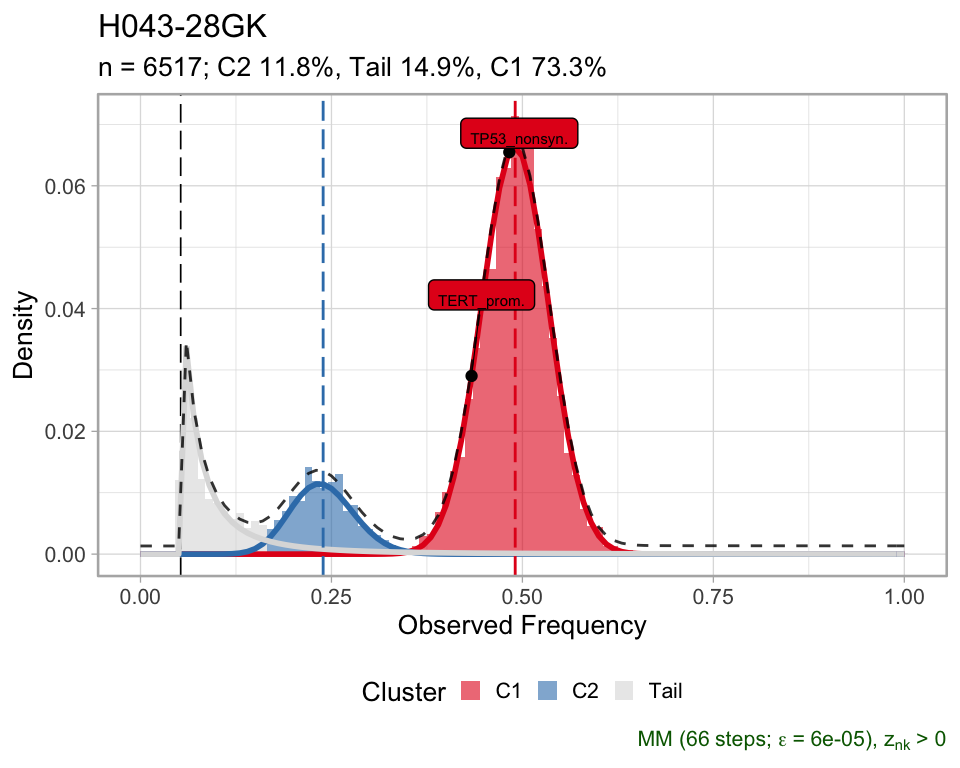

```r
# We just go faster than before
plot(mobster_analysis_CCF$best)
```

## Clone tree inference

We use the package [ctree](https://caravagn.github.io/ctree/) to cpmpute clone trees from these CCF clusters.

This package is accessed directly from `mobster`. With 1 subclone, there is one possible tree (obviously).

```r
trees = mobster::get_clone_trees(mobster_analysis_CCF$best)
```

```
#>  [ ctree ~ clone trees generator for H043-28GK ]
#>
#> # A tibble: 2 × 5
#>   cluster    R1 nMuts is.clonal is.driver
#>   <chr>   <dbl> <dbl> <lgl>     <lgl>
#> 1 C1      0.491  4807 TRUE      TRUE
#> 2 C2      0.239   839 FALSE     FALSE
#> ✔ Trees per region 1
#> There are no alternatives!
#>
#> ── Ranking trees
#> ✔ 1  trees with non-zero score, storing 1
```

```r
# Textual print
print(trees)
```

```
#> $`1`
#>  [ ctree - ctree rank 1/1 for H043-28GK ]
#>
#> # A tibble: 2 × 5
#>   cluster    R1 nMuts is.clonal is.driver
#>   <chr>   <dbl> <dbl> <lgl>     <lgl>
#> 1 C1      0.491  4807 TRUE      TRUE
#> 2 C2      0.239   839 FALSE     FALSE
#>
#> Tree shape (drivers annotated)
#>
#>   \-GL
#>    \-C1 :: TP53_nonsyn., TERT_prom.
#>     \-C2
#>
#> Information transfer
#>
#>    GL ---> TP53_nonsyn.
#>    GL ---> TERT_prom.
#>
#> Tree score 1
```

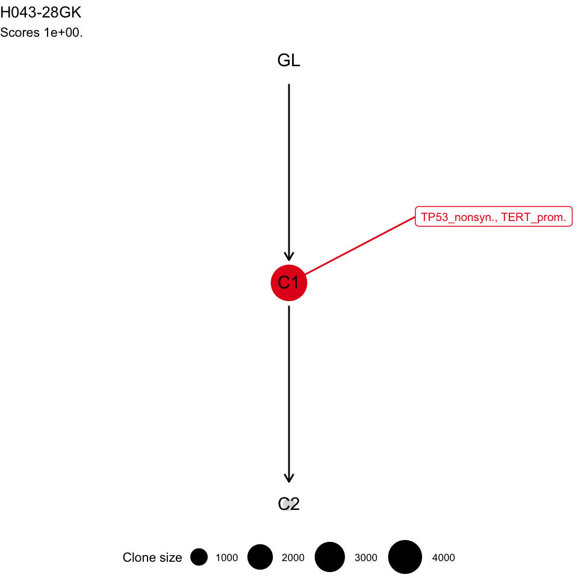

```r
# Plot the unique tree
plot(trees[[1]])
```